# Acquisition Opportunities and Challenges of Electronidex: Market Basket Analysis of Electronidex

2023-05-20

# Subtitle: Unveiling Insights from Customer Purchase Patterns

## **R Markdown**

Students will continue to work as data analysts at Blackwell Electronics. Their job is to extend Blackwell’s application of data mining methods to develop predictive models.

In this course, students will use the R statistical programming language augmented with machine learning packages to predict different product types a customer will be likely to buy. Next, students will create a recommender system that recommends additional purchases based on customer choices. Finally, students will present to management, explaining their insights and suggestions for data mining process improvements.

## Task

Market Basket Analysis Hi,

Blackwell Electronics’ board of directors is considering acquiring Electronidex, a start-up electronics online retailer. The board of directors has asked us to help them better understand the clientele that Electronidex currently is serving and if it would be an optimal partnership.

They need our help to identify purchasing patterns that will provide insight into Electronidex’s clientele. Attached is a CSV file that contains one month’s (30 days’ worth) of Electronidexes online transactions and a file containing all the electronics that they currently sell. Due to their lack of funding, Electronidex is only able to pull data on the items that customers purchased per their transactions.

I would like you to to use R to conduct a market basket analysis. You will be discovering any interesting relationships (or associations) between customer’s transactions and the item(s) they’ve purchased. These associations can then be used to drive sales-oriented initiatives such as recommender systems like the ones used by Amazon and other eCommerce sites.

To help Blackwell’s board of directors form a clearer picture of Electronidex’s customer buying patterns, please consider the following questions while you’re performing your analysis:

- **Are there any interesting patterns or item relationships within Electronidex’s transactions?**
- **Would Blackwell benefit from selling any of Electronidex’s items?**
- **In your opinion, should Blackwell acquire Electronidex?**
- **If Blackwell does acquire Electronidex, do you have any recommendations for Blackwell? (Ex: cross-selling items, sale promotions, should they remove items, etc.)**

Once you’ve completed your market basket analysis, please put together a formal business report in Word. Thank you in advance!

Best,

Danielle Sherman Chief Technology Officer Blackwell Electronics www.blackwellelectronics.com

### Loading and installing required packages

```r
suppressPackageStartupMessages(library(arulesViz))
suppressPackageStartupMessages(library(arules))
suppressPackageStartupMessages(library(tidyverse))
library(readxl)
library(knitr)
library(ggplot2)
library(lubridate)
library(rmarkdown)
library(stringr)
library(RColorBrewer)
```

### Loading Datasets

```r
df_product <- read.csv("ElectronidexTransactions2017.csv", header = FALSE, sep = ",")
product <- read.transactions("ElectronidexTransactions2017.csv", format = "basket", sep = ",")
blackwellold <- read.csv("existingproductattributes2017.csv")
blackwellnew <- read.csv("newproductattributes2017.csv")
Product_Equivalence <- read.csv("product.csv", header = TRUE, sep = ";")
```

NOTE:

- **ElectronidexTransactions.csv, is a record of one month’s (30 days’ worth) of 9835 online transactions and which items were purchased out of the 125 products Electronidex sells.**
- **The file, product.csv, is an equivalence list between the Product and Category sold by Electronidex, with 125 products that Electronidex sells broken down into 17 product types.**

### Equivalence dataframe

```r
equivalence <- data.frame(
  Category_Blackwell = c(
    "NULL", "PC & Laptop & Netbook", "Accessories", "Software", "Display", "Printer",
    "Printer Supplies", "Extended Warranty", "Tablet", "Smartphone", "Game Console", "NULL",
    "NULL", "NULL", "NULL", "NULL"
  ),
  Category_Electronidex = c(
    "Desktop", "Laptop",
    "Accessories, Computer Stands, Mouse and Keyboard Combo, Computer Cords, Computer Mice, Keyboard",
    "NULL", "Monitors", "Printer", "Printer Ink", "NULL", "Computer Tablets", "NULL",
    "NULL", "Speakers", "External Hard Drives", "Smart Home Devices",
    "Computer Headphones", "Active Headphones"
  )
)
equivalence
```

| Category_Blackwell | Category_Electronidex |
| --- | --- |
| NULL | Desktop |
| PC & Laptop & Netbook | Laptop |
| Accessories | Accessories, Computer Stands, Mouse and Keyboard Combo, Computer Cords, Computer Mice, Keyboard |
| Software | NULL |
| Display | Monitors |
| Printer | Printer |
| Printer Supplies | Printer Ink |
| Extended Warranty | NULL |
| Tablet | Computer Tablets |
| Smartphone | NULL |

[output cut: 6 more lines]

Comment:

- This **equivalence** table serves as a guidethrough to understand the categories present in Blackwell’s category potfolio which are also present in Electronidex. They are several categoriws which are NULL, which means that they do not have a correspondent equivalent, these are values in which the category is present in one of the stores but not on the other and viceversa.

# Categories present in Blackwell:

- 1. PC & Laptop = Laptop
- 3. Accessories
- 4. Software
- 5. Display
- 6. Printer
- 7. Printer Supplies
- 8. Extended Warranty
- 9. Netbook
- 10. Tablet
- 11. Smartphone
- 12. Game Console

# Categories present in Electronidex:

- 1. Desktop
- 2. Laptop
- 3. Monitors
- 4. Computer Mice
- 5. Keyboard
- 6. Mouse and Keyboard Combo
- 7. Computer Headphones
- 8. Active Headphones
- 9. Computer Cords
- 10. Accessories
- 11. Speakers
- 12. Printers
- 13. Printer Ink
- 14. Computer Stands
- 15. Computer Tablets
- 16. External Hard Drives
- 17. Smart Home Devices

# Preprocessing

```r
# Create an empty dataframe for df_copy

df_category <- data.frame(matrix(nrow = nrow(Product_Equivalence), ncol = ncol(Product_Equivalence)))
```

```r
# Create an empty dataframe df_category with the same dimensions as df_product
df_category <- data.frame(matrix(nrow = nrow(df_product), ncol = ncol(df_product)))

# Loop through the indices of df_product
#for (i in 1:nrow(df_product)) {
#  try({
#    for (e in 1:ncol(df_product)) {
#      print(i)
#      if (nchar(str_trim(df_product[i, e])) == 0) {
#        df_category[i, e] <- df_product[i, e]
#      } else {
#        df_category[i, e] <- Product_Equivalence[which(Product_Equivalence$producto == str_trim(df_product[i, e])), 1]
#        print(str_trim(df_product[i, e]))
#        print(Product_Equivalence[which(Product_Equivalence$producto == str_trim(df_product[i, e])), 1])
#      }
#    }
#  })
#}
```

```r
#Write df_copy to a CSV file
#write.csv(df_category, "category.csv", row.names = FALSE)

# Read transactions from the CSV file into category
df_category <- read.csv("category.csv", sep = ",")
category <- read.transactions("category.csv", format = "basket", sep = ",")
```

COMMENT:

Based on the information above:

- df represents the data in the file “ElectronidexTransactions.csv”. It contains records of 9835 online transactions that occurred over a period of 30 days. Each transaction entry includes information about the purchased items from the 125 products sold by Electronidex.
- dfproduct represents the data in the file “product.csv”. It is an equivalence list that maps the products sold by Electronidex to their respective categories. It contains 125 rows, each representing a product, and includes information about the category to which each product belongs. The categories are broken down into 17 product types.

**The purpose of the code is to create a copy of the df dataframe named df_copy with corresponding category information from dfproduct.** The code iterates over each row and column of df, checks if the value in df is empty, and if not, searches for the matching product in dfproduct. It then assigns the corresponding category value from dfproduct to the df_copy dataframe.

**This code essentially enhances the df dataframe by including the category information from dfproduct, providing a more comprehensive representation of the transactions with the corresponding product categories.**

# Exploratory Data Analysis Category - Using the arules and arulesviz package.

```r
# Exploratory Data Analysis (EDA) - category

# View the transactions in category

#inspect(category)

# Check the number of transactions
length(category)  # 9836 Number of transactions.
```

```
## [1] 9836
```

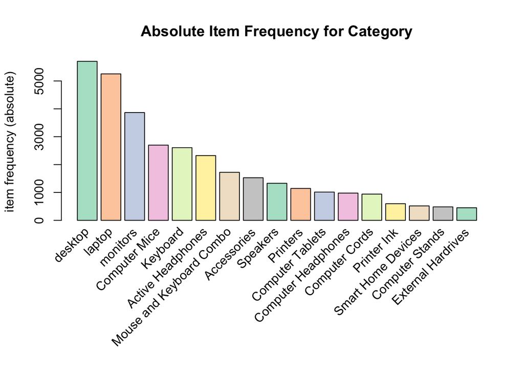

```r
# Check the number of items per transaction
#size(category)  # Number of items per transaction

# List the transactions by conversion (LIST must be capitalized)
#LIST(category)

# View the item labels
#itemLabels(category)

# Summary statistics of the category
#summary(category)

# Item frequency plot for the category

itemFrequencyPlot(category, topN = 17, type = "absolute", col = brewer.pal(8, 'Pastel2'), main = "Absolute Item Frequency for Category")
```

```r
category
```

```
## transactions in sparse format with
##  9836 transactions (rows) and
##  49 items (columns)
```

```r
# Exploratory Data Analysis (EDA) - product

# View the transactions in product

#inspect(product)

# Check the number of transactions
length(product)  # 9836 Number of transactions.
```

```
## [1] 9835
```

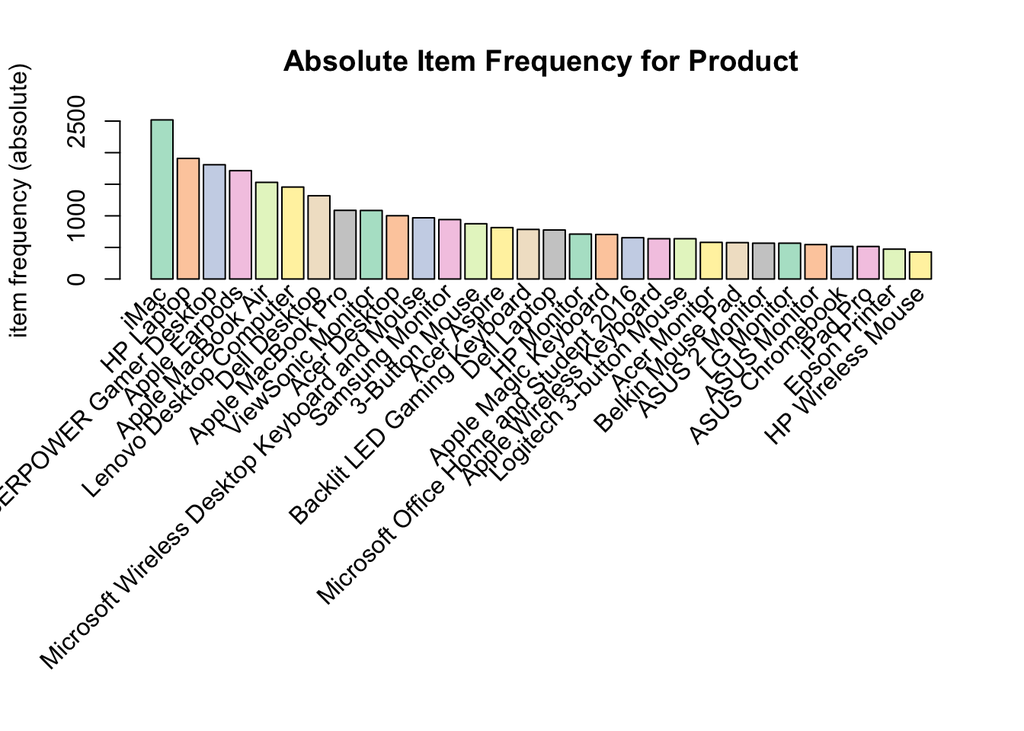

```r
# Check the number of items per transaction
#size(product)  # Number of items per transaction

# List the transactions by conversion (LIST must be capitalized)
#LIST(product)

# View the item labels
#itemLabels(product)

# Summary statistics of the product
#summary(product)

# Item frequency plot for the product
if (!require("RColorBrewer")) {
  install.packages("RColorBrewer")
  library(RColorBrewer)
}
itemFrequencyPlot(product, topN = 30, type = "absolute", col = brewer.pal(8, 'Pastel2'), main = "Absolute Item Frequency for Product")
```

```r
rules_cat <- apriori(category, parameter = list(supp=0.005, conf=0.5))
```

```
## Apriori
##
## Parameter specification:
##  confidence minval smax arem  aval originalSupport maxtime support minlen
##         0.5    0.1    1 none FALSE            TRUE       5   0.005      1
##  maxlen target  ext
##      10  rules TRUE
##
## Algorithmic control:
##  filter tree heap memopt load sort verbose
##     0.1 TRUE TRUE  FALSE TRUE    2    TRUE
##
## Absolute minimum support count: 49
##
## set item appearances ...[0 item(s)] done [0.00s].
## set transactions ...[49 item(s), 9836 transaction(s)] done [0.00s].
## sorting and recoding items ... [17 item(s)] done [0.00s].
## creating transaction tree ... done [0.00s].
## checking subsets of size 1 2 3 4 5 6 7 done [0.00s].
## writing ... [3387 rule(s)] done [0.00s].
## creating S4 object  ... done [0.00s].
```

```r
rules_cat<- subset(rules_cat, lift > 1)
rules_cat <- sort(rules_cat, by='supp', decreasing = TRUE)
rules_cat <- rules_cat[!is.redundant(rules_cat)]
gi <- generatingItemsets(rules_cat)
d <- which(duplicated(gi))
rules_cat<-rules_cat[-d]
summary(rules_cat)
```

```
## set of 1579 rules
##
## rule length distribution (lhs + rhs):sizes
##   2   3   4   5   6   7
##  41 332 653 436 112   5
##
##    Min. 1st Qu.  Median    Mean 3rd Qu.    Max.
##   2.000   4.000   4.000   4.165   5.000   7.000
##
## summary of quality measures:
##     support           confidence        coverage             lift
##  Min.   :0.005083   Min.   :0.5000   Min.   :0.005287   Min.   :1.035
##  1st Qu.:0.006405   1st Qu.:0.7440   1st Qu.:0.008032   1st Qu.:1.444
##  Median :0.008743   Median :0.8156   Median :0.011387   Median :1.524
##  Mean   :0.015233   Mean   :0.7926   Mean   :0.020464   Mean   :1.589
##  3rd Qu.:0.014742   3rd Qu.:0.8687   3rd Qu.:0.019164   3rd Qu.:1.659
##  Max.   :0.320557   Max.   :0.9808   Max.   :0.534160   Max.   :2.532
##      count
##  Min.   :  50.0
##  1st Qu.:  63.0
##  Median :  86.0
##  Mean   : 149.8
##  3rd Qu.: 145.0
##  Max.   :3153.0
##
## mining info:
##      data ntransactions support confidence
##  category          9836   0.005        0.5
##                                                                  call
##  apriori(data = category, parameter = list(supp = 0.005, conf = 0.5))
```

```
## To reduce overplotting, jitter is added! Use jitter = 0 to prevent jitter.
```

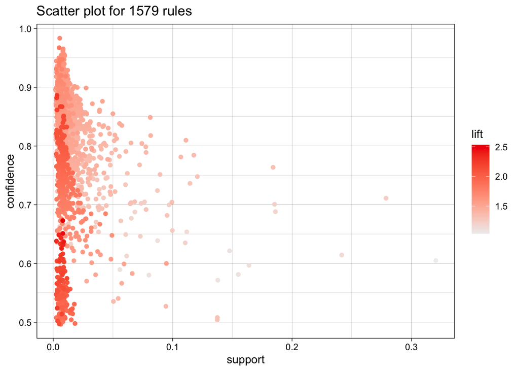

```r
plot(rules_cat, measure = c("support", "confidence"), shading = "lift")
```

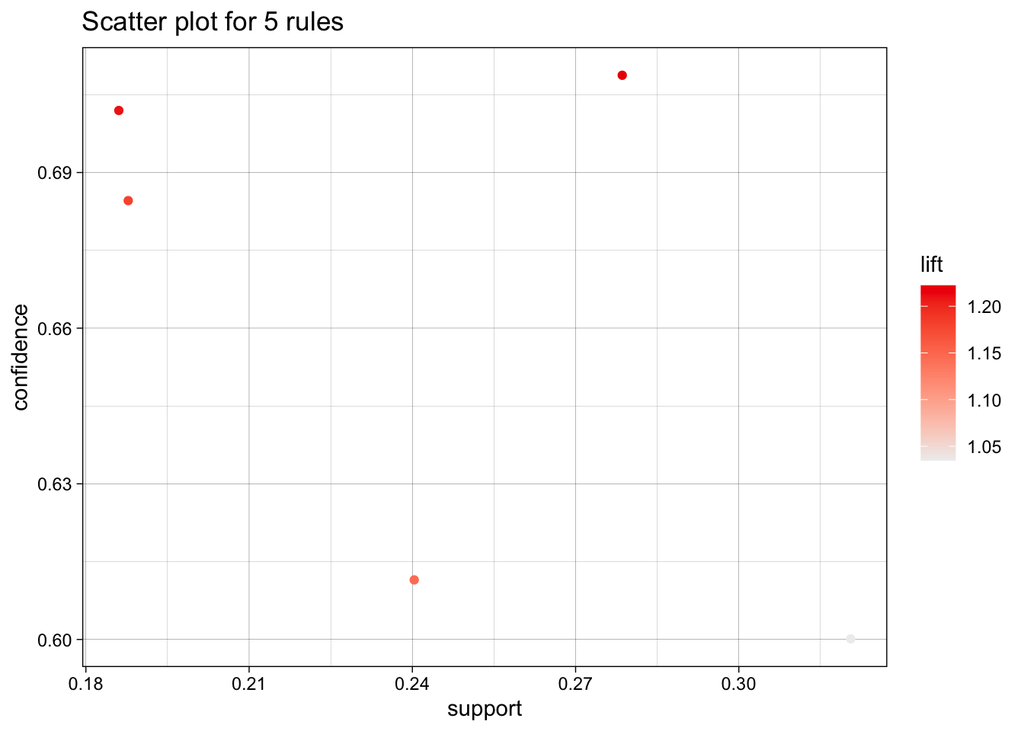

```r
topRules <- rules_cat[1:5]
plot(topRules, jitter=0)
```

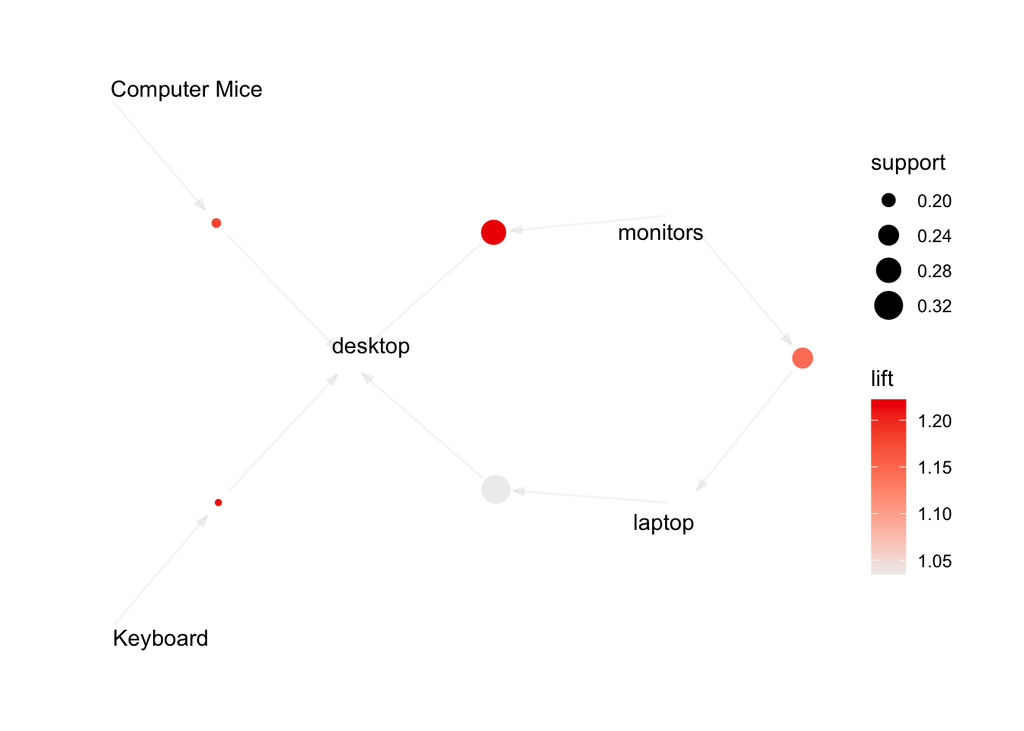

```r
plot(head(sort(topRules, by = "lift")), method = "graph")
```

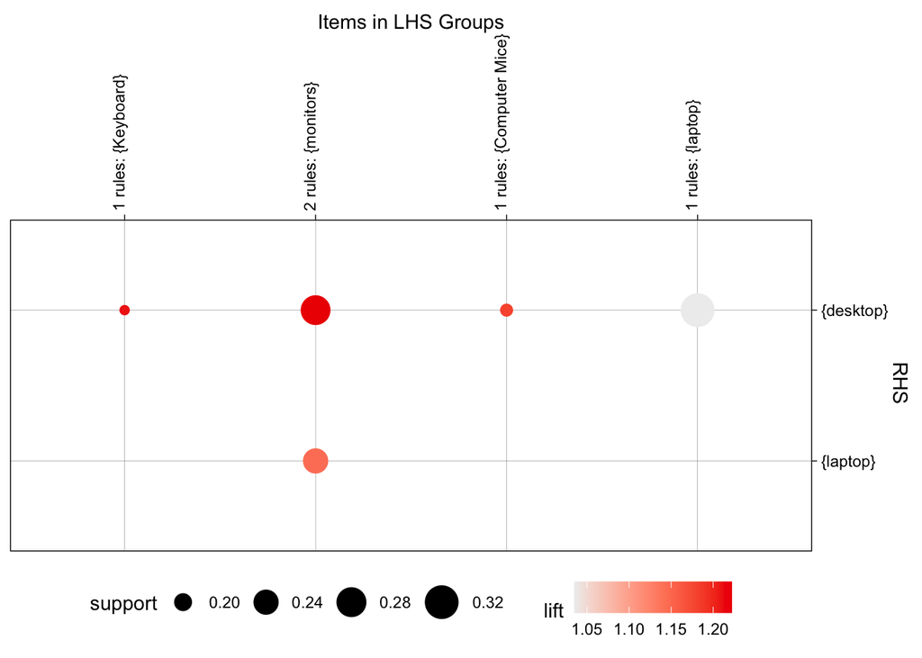

```r
plot(topRules, method="grouped")
```

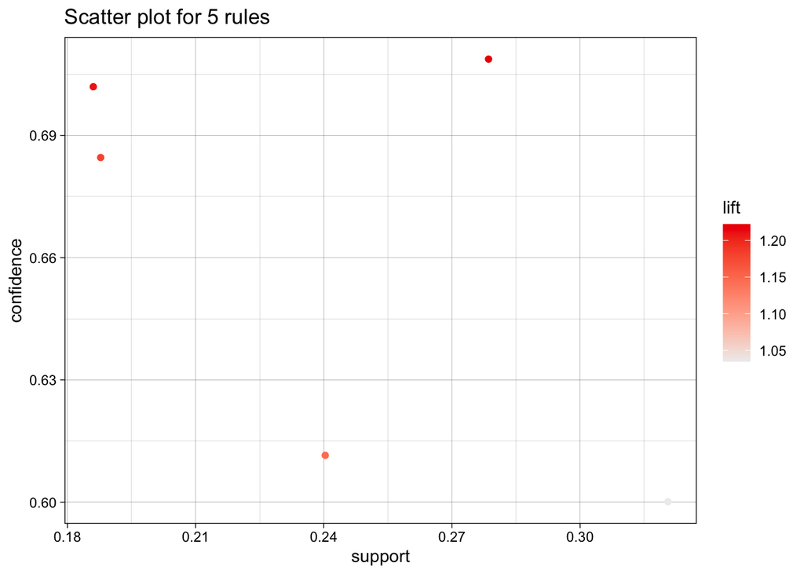

```r
plot(topRules)
```

```r
inspectDT(topRules)
```

|  | LHS | RHS | support | confidence | coverage | lift | count |
| --- | --- | --- | --- | --- | --- | --- | --- |
| [44] | {laptop} | {desktop} | 0.32055713704758 | 0.600114198705748 | 0.534160227734852 | 1.03483928093789 | 3153 |
| [43] | {monitors} | {desktop} | 0.278568523790159 | 0.708742886704604 | 0.393045953639691 | 1.22215901711544 | 2740 |
| [42] | {monitors} | {laptop} | 0.240341602277349 | 0.61148473874806 | 0.393045953639691 | 1.14475901985647 | 2364 |
| [41] | {Computer Mice} | {desktop} | 0.187779585197235 | 0.684581171237954 | 0.274298495323302 | 1.18049446008003 | 1847 |
| [38] | {Keyboard} | {desktop} | 0.186051240341602 | 0.701956271576525 | 0.265046766978447 | 1.21045615133708 | 1830 |

```r
rules_prod <- apriori(product, parameter = list(supp=0.01, conf=0.25))
```

```
## Apriori
##
## Parameter specification:
##  confidence minval smax arem  aval originalSupport maxtime support minlen
##        0.25    0.1    1 none FALSE            TRUE       5    0.01      1
##  maxlen target  ext
##      10  rules TRUE
##
## Algorithmic control:
##  filter tree heap memopt load sort verbose
##     0.1 TRUE TRUE  FALSE TRUE    2    TRUE
##
## Absolute minimum support count: 98
##
## set item appearances ...[0 item(s)] done [0.00s].
## set transactions ...[125 item(s), 9835 transaction(s)] done [0.00s].
## sorting and recoding items ... [82 item(s)] done [0.00s].
## creating transaction tree ... done [0.00s].
## checking subsets of size 1 2 3 4 done [0.00s].
## writing ... [204 rule(s)] done [0.00s].
## creating S4 object  ... done [0.00s].
```

```r
rules_prod <- subset(rules_prod, lift > 1)
rules_prod <- sort(rules_prod, by='lift', decreasing = TRUE)
rules_prod <- rules_prod[!is.redundant(rules_prod)]
summary(rules_prod)
```

```
## set of 201 rules
##
## rule length distribution (lhs + rhs):sizes
##   2   3
## 102  99
##
##    Min. 1st Qu.  Median    Mean 3rd Qu.    Max.
##   2.000   2.000   2.000   2.493   3.000   3.000
##
## summary of quality measures:
##     support          confidence        coverage            lift
##  Min.   :0.01007   Min.   :0.2500   Min.   :0.01739   Min.   :1.155
##  1st Qu.:0.01118   1st Qu.:0.3055   1st Qu.:0.03071   1st Qu.:1.596
##  Median :0.01474   Median :0.3578   Median :0.04209   Median :1.851
##  Mean   :0.01814   Mean   :0.3720   Mean   :0.05154   Mean   :1.914
##  3rd Qu.:0.02105   3rd Qu.:0.4286   3rd Qu.:0.05877   3rd Qu.:2.190
##  Max.   :0.07555   Max.   :0.6023   Max.   :0.25613   Max.   :3.360
##      count
##  Min.   : 99.0
##  1st Qu.:110.0
##  Median :145.0
##  Mean   :178.4
##  3rd Qu.:207.0
##  Max.   :743.0
##
## mining info:
##     data ntransactions support confidence
##  product          9835    0.01       0.25
##                                                                 call
##  apriori(data = product, parameter = list(supp = 0.01, conf = 0.25))
```

```r
gi <- generatingItemsets(rules_prod)
d <- which(duplicated(gi))
rules_prod <-rules_prod[-d]
summary(rules_prod)
```

```
## set of 145 rules
##
## rule length distribution (lhs + rhs):sizes
##   2   3
## 101  44
##
##    Min. 1st Qu.  Median    Mean 3rd Qu.    Max.
##   2.000   2.000   2.000   2.303   3.000   3.000
##
## summary of quality measures:
##     support          confidence        coverage            lift
##  Min.   :0.01007   Min.   :0.2500   Min.   :0.01901   Min.   :1.155
##  1st Qu.:0.01149   1st Qu.:0.2920   1st Qu.:0.03416   1st Qu.:1.518
##  Median :0.01576   Median :0.3421   Median :0.04616   Median :1.795
##  Mean   :0.01931   Mean   :0.3519   Mean   :0.05650   Mean   :1.872
##  3rd Qu.:0.02267   3rd Qu.:0.3947   3rd Qu.:0.07168   3rd Qu.:2.156
##  Max.   :0.07555   Max.   :0.5829   Max.   :0.19410   Max.   :3.360
##      count
##  Min.   : 99.0
##  1st Qu.:113.0
##  Median :155.0
##  Mean   :189.9
##  3rd Qu.:223.0
##  Max.   :743.0
##
## mining info:
##     data ntransactions support confidence
##  product          9835    0.01       0.25
##                                                                 call
##  apriori(data = product, parameter = list(supp = 0.01, conf = 0.25))
```

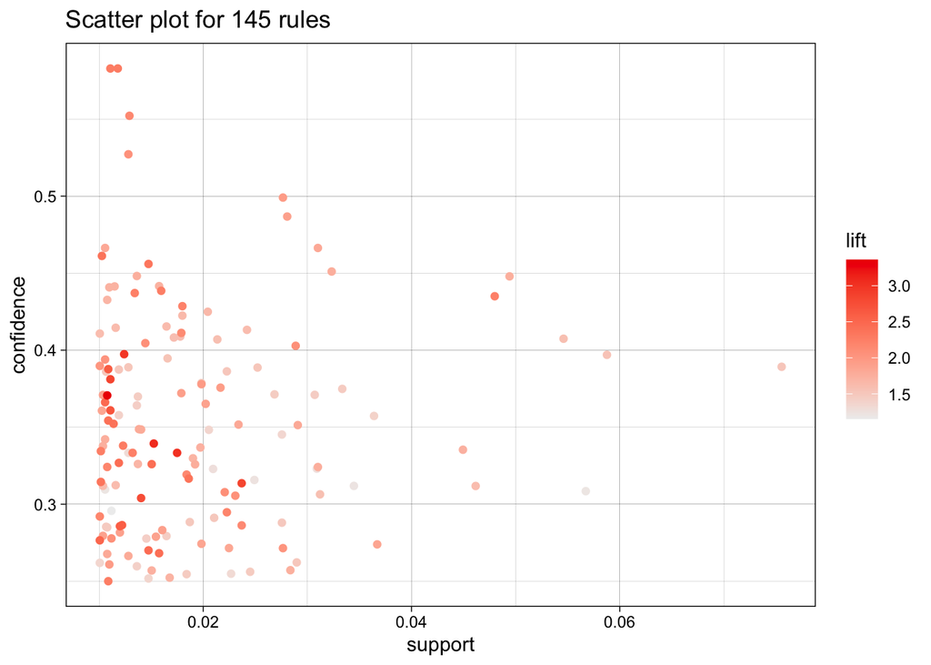

```r
plot(rules_prod, measure = c("support", "confidence"), shading = "lift")
```

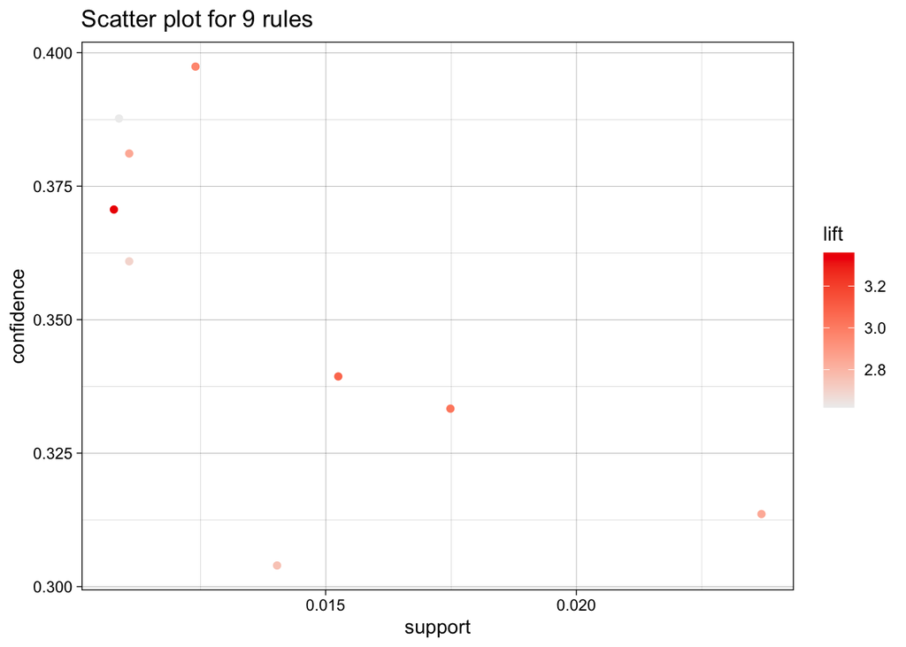

```r
topRules <- rules_prod[1:9]
plot(topRules, jitter=0)
```

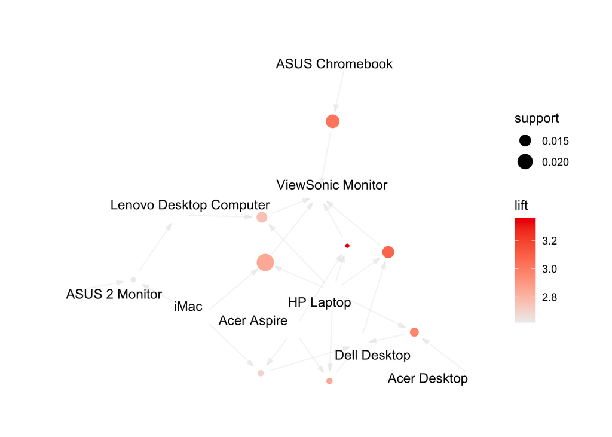

```r
plot(head(sort(topRules, by = "lift"), 22), method = "graph")
```

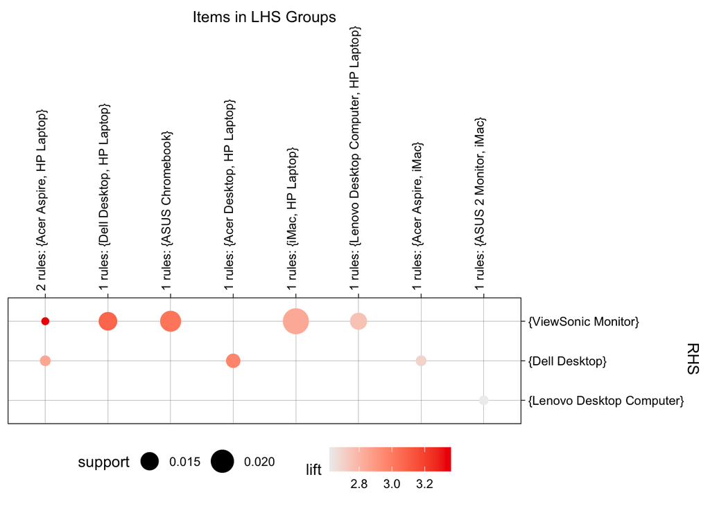

```r
plot(topRules, method="grouped")
```

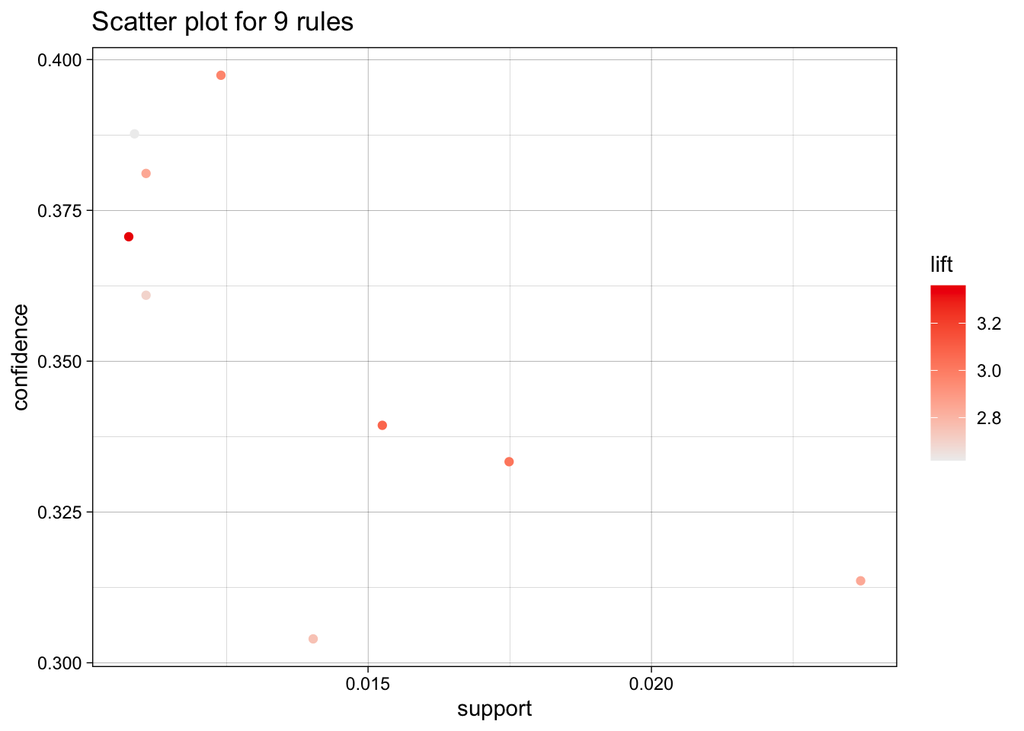

```r
plot(topRules)
```

```r
inspectDT(rules_prod)
```

|  | LHS | RHS | support | confidence | coverage | lift | count |
| --- | --- | --- | --- | --- | --- | --- | --- |
| [127] | {Acer Aspire,HP Laptop} | {ViewSonic Monitor} | 0.0107778342653787 | 0.370629370629371 | 0.0290798169801729 | 3.359575907963 | 106 |
| [157] | {Dell Desktop,HP Laptop} | {ViewSonic Monitor} | 0.0152516522623284 | 0.339366515837104 | 0.0449415353329944 | 3.07619325645891 | 150 |
| [42] | {ASUS Chromebook} | {ViewSonic Monitor} | 0.0174885612608033 | 0.333333333333333 | 0.0524656837824098 | 3.02150537634409 | 172 |
| [147] | {Acer Desktop,HP Laptop} | {Dell Desktop} | 0.0124046771733604 | 0.397394136807818 | 0.0312150482968988 | 2.96538037595211 | 122 |
| [129] | {Acer Aspire,HP Laptop} | {Dell Desktop} | 0.0110828673106253 | 0.381118881118881 | 0.0290798169801729 | 2.84393338073156 | 109 |
| [174] | {HP Laptop,iMac} | {ViewSonic Monitor} | 0.0236908998474835 | 0.313593539703903 | 0.0755465175394001 | 2.84257369860635 | 233 |
| [168] | {HP Laptop,Lenovo Desktop Computer} | {ViewSonic Monitor} | 0.0140315200813421 | 0.303964757709251 | 0.0461616675139807 | 2.75529344891289 | 138 |
| [131] | {Acer Aspire,iMac} | {Dell Desktop} | 0.0110828673106253 | 0.360927152317881 | 0.0307066598881546 | 2.69326141354048 | 109 |
| [107] | {ASUS 2 Monitor,iMac} | {Lenovo Desktop Computer} | 0.0108795119471276 | 0.38768115942029 | 0.0280630401626843 | 2.61871167781494 | 107 |
| [163] | {CYBERPOWER Gamer Desktop,HP Laptop} | {ViewSonic Monitor} | 0.0122013218098627 | 0.286396181384248 | 0.0426029486527707 | 2.59604280545077 | 120 |

[output cut: 135 more lines]

```r
Cat_Rules1 <- subset(rules_cat, items %in% "desktop")
CatRules1 <- sort(Cat_Rules1, by = "support", decreasing = TRUE)
top5_categories <- head(CatRules1, 5)
head(top5_categories)
```

```
## set of 5 rules
```

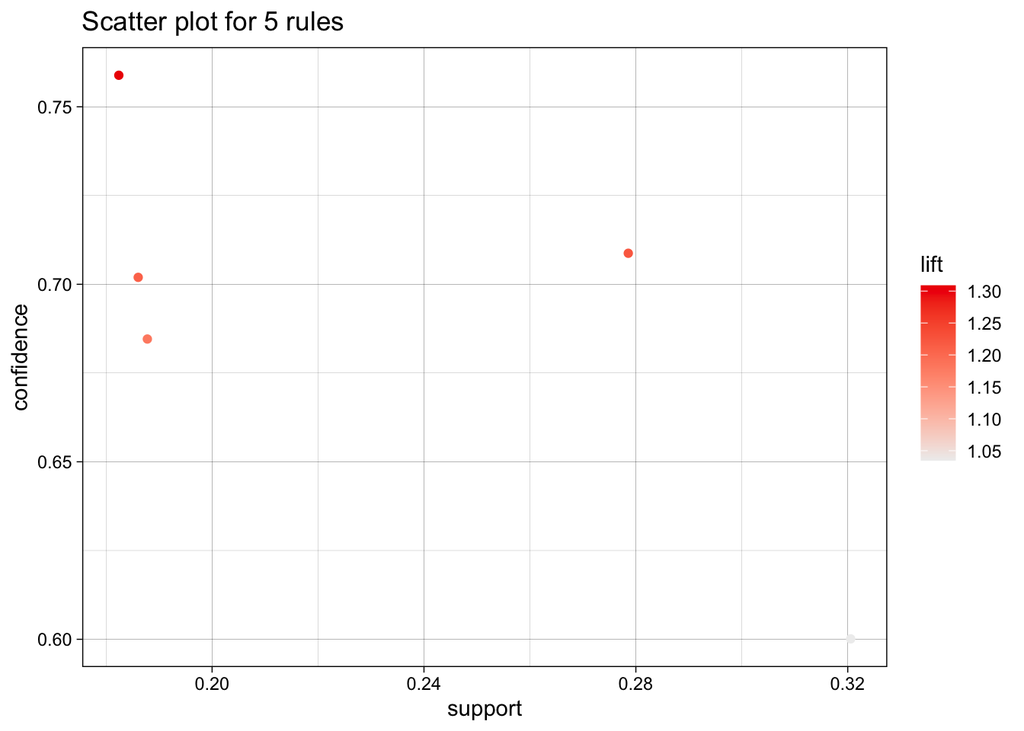

```r
plot(top5_categories)
```

```r
inspectDT(top5_categories)
```

|  | LHS | RHS | support | confidence | coverage | lift | count |
| --- | --- | --- | --- | --- | --- | --- | --- |
| [44] | {laptop} | {desktop} | 0.32055713704758 | 0.600114198705748 | 0.534160227734852 | 1.03483928093789 | 3153 |
| [43] | {monitors} | {desktop} | 0.278568523790159 | 0.708742886704604 | 0.393045953639691 | 1.22215901711544 | 2740 |
| [41] | {Computer Mice} | {desktop} | 0.187779585197235 | 0.684581171237954 | 0.274298495323302 | 1.18049446008003 | 1847 |
| [38] | {Keyboard} | {desktop} | 0.186051240341602 | 0.701956271576525 | 0.265046766978447 | 1.21045615133708 | 1830 |
| [419] | {laptop,monitors} | {desktop} | 0.18239121594144 | 0.758883248730964 | 0.240341602277349 | 1.30862125429835 | 1794 |

COMMENT:

```r
Cat_Rules2 <- subset(rules_cat, items %in% "laptop")
CatRules2 <- sort(Cat_Rules2, by = "support", decreasing = TRUE)
top5_categories <- head(CatRules2, 5)
head(top5_categories)
```

```
## set of 5 rules
```

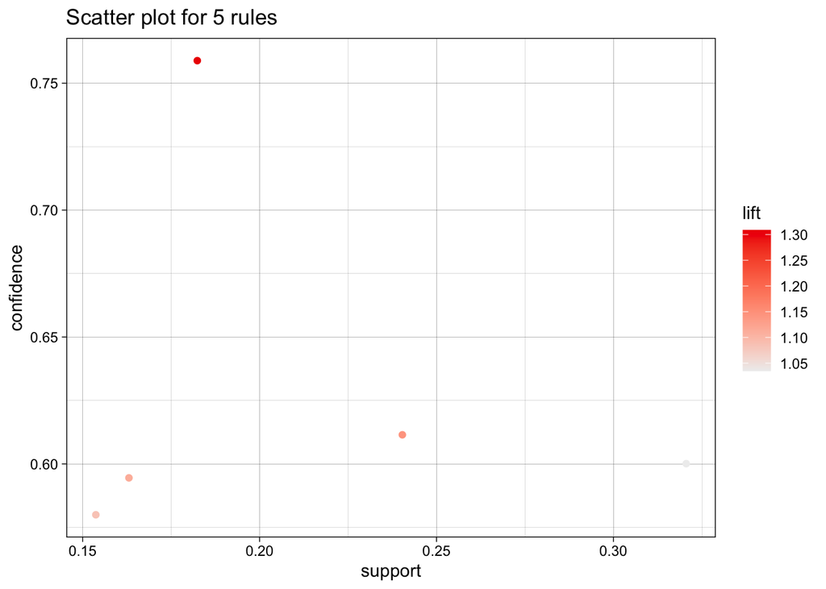

```r
plot(top5_categories)
```

```r
inspectDT(top5_categories)
```

|  | LHS | RHS | support | confidence | coverage | lift | count |
| --- | --- | --- | --- | --- | --- | --- | --- |
| [44] | {laptop} | {desktop} | 0.32055713704758 | 0.600114198705748 | 0.534160227734852 | 1.03483928093789 | 3153 |
| [42] | {monitors} | {laptop} | 0.240341602277349 | 0.61148473874806 | 0.393045953639691 | 1.14475901985647 | 2364 |
| [419] | {laptop,monitors} | {desktop} | 0.18239121594144 | 0.758883248730964 | 0.240341602277349 | 1.30862125429835 | 1794 |
| [40] | {Computer Mice} | {laptop} | 0.163074420496137 | 0.594514455151964 | 0.274298495323302 | 1.11298899521788 | 1604 |
| [37] | {Keyboard} | {laptop} | 0.153721024806832 | 0.579976985040276 | 0.265046766978447 | 1.0857734344987 | 1512 |

Comment:

```r
Cat_Rules3 <- subset(rules_cat, items %in% "monitors")
CatRules3 <- sort(Cat_Rules3, by = "support", decreasing = TRUE)
top5_categories <- head(CatRules3, 5)
head(top5_categories)
```

```
## set of 5 rules
```

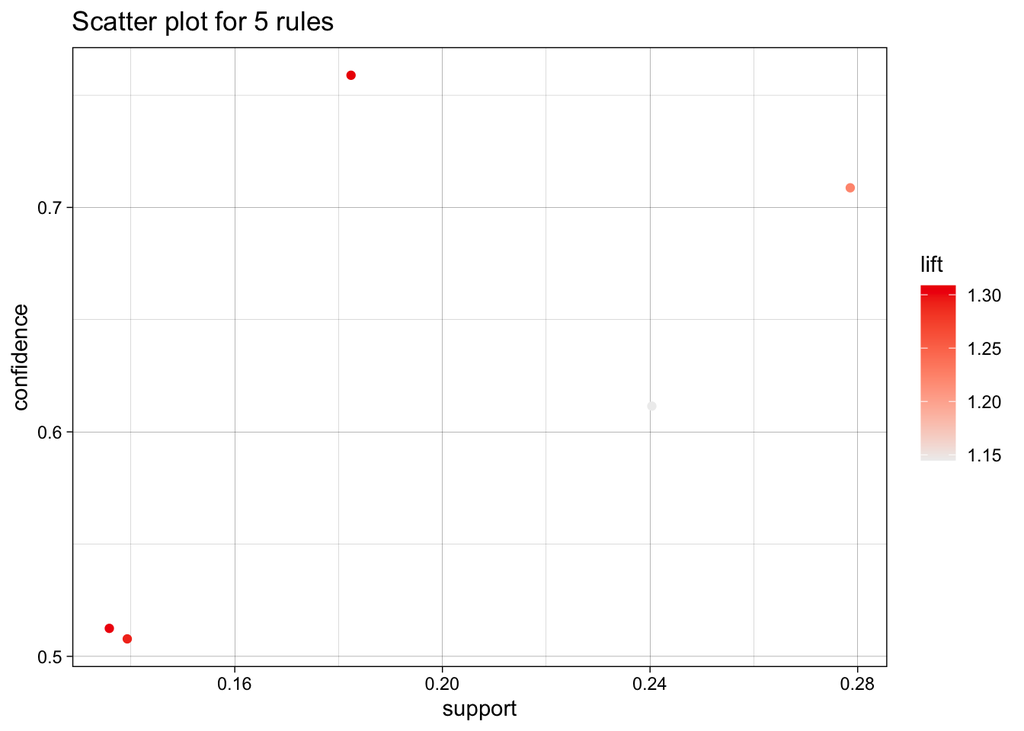

```r
plot(top5_categories)
```

```r
inspectDT(top5_categories)
```

|  | LHS | RHS | support | confidence | coverage | lift | count |
| --- | --- | --- | --- | --- | --- | --- | --- |
| [43] | {monitors} | {desktop} | 0.278568523790159 | 0.708742886704604 | 0.393045953639691 | 1.22215901711544 | 2740 |
| [42] | {monitors} | {laptop} | 0.240341602277349 | 0.61148473874806 | 0.393045953639691 | 1.14475901985647 | 2364 |
| [419] | {laptop,monitors} | {desktop} | 0.18239121594144 | 0.758883248730964 | 0.240341602277349 | 1.30862125429835 | 1794 |
| [39] | {Computer Mice} | {monitors} | 0.139284261895079 | 0.507783543365456 | 0.274298495323302 | 1.29191902031625 | 1370 |
| [36] | {Keyboard} | {monitors} | 0.135827572183815 | 0.512466436517069 | 0.265046766978446 | 1.30383338582046 | 1336 |

Comment:

```r
rules_product <- apriori(product, parameter = list(support = 0.01, confidence = 0.5))
```

```
## Apriori
##
## Parameter specification:
##  confidence minval smax arem  aval originalSupport maxtime support minlen
##         0.5    0.1    1 none FALSE            TRUE       5    0.01      1
##  maxlen target  ext
##      10  rules TRUE
##
## Algorithmic control:
##  filter tree heap memopt load sort verbose
##     0.1 TRUE TRUE  FALSE TRUE    2    TRUE
##
## Absolute minimum support count: 98
##
## set item appearances ...[0 item(s)] done [0.00s].
## set transactions ...[125 item(s), 9835 transaction(s)] done [0.00s].
## sorting and recoding items ... [82 item(s)] done [0.00s].
## creating transaction tree ... done [0.00s].
## checking subsets of size 1 2 3 4 done [0.00s].
## writing ... [19 rule(s)] done [0.00s].
## creating S4 object  ... done [0.00s].
```

```r
sorted_rules <- sort(rules_product, by = "support", decreasing = TRUE)
sorted_rules
```

```
## set of 19 rules
```

```r
top5_products <- head(sorted_rules, 5)
head(top5_products)
```

```
## set of 5 rules
```

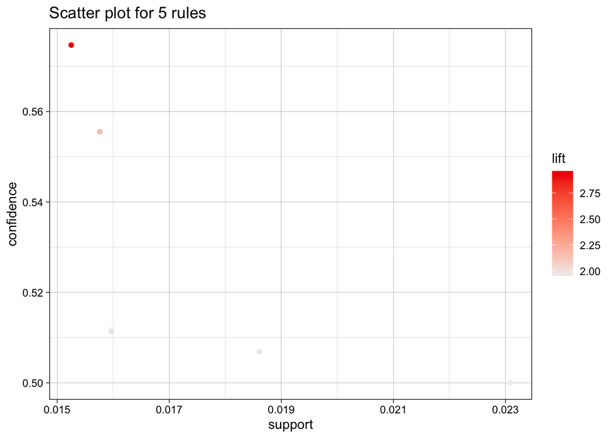

```r
plot(top5_products)
```

```r
inspectDT(top5_products)
```

|  | LHS | RHS | support | confidence | coverage | lift | count |
| --- | --- | --- | --- | --- | --- | --- | --- |
| [19] | {HP Laptop,Lenovo Desktop Computer} | {iMac} | 0.0230808337569903 | 0.5 | 0.0461616675139807 | 1.95216355696705 | 227 |
| [18] | {Dell Desktop,Lenovo Desktop Computer} | {iMac} | 0.0186070157600407 | 0.506925207756233 | 0.0367056431113371 | 1.97920183337934 | 183 |
| [12] | {Acer Desktop,HP Laptop} | {iMac} | 0.0159633960345704 | 0.511400651465798 | 0.0312150482968988 | 1.99667542960148 | 157 |
| [17] | {Lenovo Desktop Computer,ViewSonic Monitor} | {iMac} | 0.0157600406710727 | 0.555555555555556 | 0.0283680732079309 | 2.16907061885228 | 155 |
| [13] | {Dell Desktop,ViewSonic Monitor} | {HP Laptop} | 0.0152516522623284 | 0.574712643678161 | 0.0265378749364515 | 2.96086896310881 | 150 |

```r
Item_Rules<- subset(rules_product, items %in% "iMac")
ItemRules <- sort(Item_Rules, by = "support", decreasing = TRUE)
top5_products <- head(ItemRules, 5)
head(top5_products)
```

```
## set of 5 rules
```

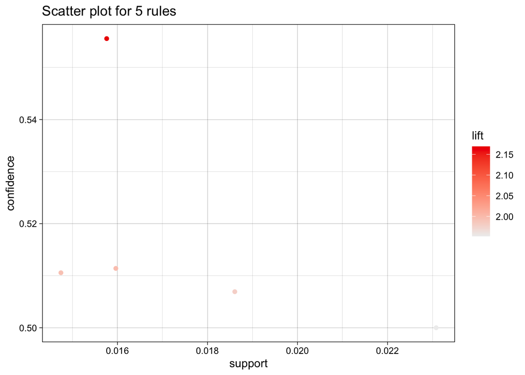

```r
plot(top5_products)
```

```r
inspectDT(top5_products)
```

|  | LHS | RHS | support | confidence | coverage | lift | count |
| --- | --- | --- | --- | --- | --- | --- | --- |
| [19] | {HP Laptop,Lenovo Desktop Computer} | {iMac} | 0.0230808337569903 | 0.5 | 0.0461616675139807 | 1.95216355696705 | 227 |
| [18] | {Dell Desktop,Lenovo Desktop Computer} | {iMac} | 0.0186070157600407 | 0.506925207756233 | 0.0367056431113371 | 1.97920183337934 | 183 |
| [12] | {Acer Desktop,HP Laptop} | {iMac} | 0.0159633960345704 | 0.511400651465798 | 0.0312150482968988 | 1.99667542960148 | 157 |
| [17] | {Lenovo Desktop Computer,ViewSonic Monitor} | {iMac} | 0.0157600406710727 | 0.555555555555556 | 0.0283680732079309 | 2.16907061885228 | 155 |
| [8] | {Apple Magic Keyboard,HP Laptop} | {iMac} | 0.0147432638535841 | 0.51056338028169 | 0.0288764616166751 | 1.99340644901565 | 145 |

```r
Item_Rules1<- subset(rules_product, items %in% "HP Laptop")
ItemRules1 <- sort(Item_Rules1, by = "support", decreasing = TRUE)
top5_products <- head(ItemRules1, 5)
head(top5_products)
```

```
## set of 5 rules
```

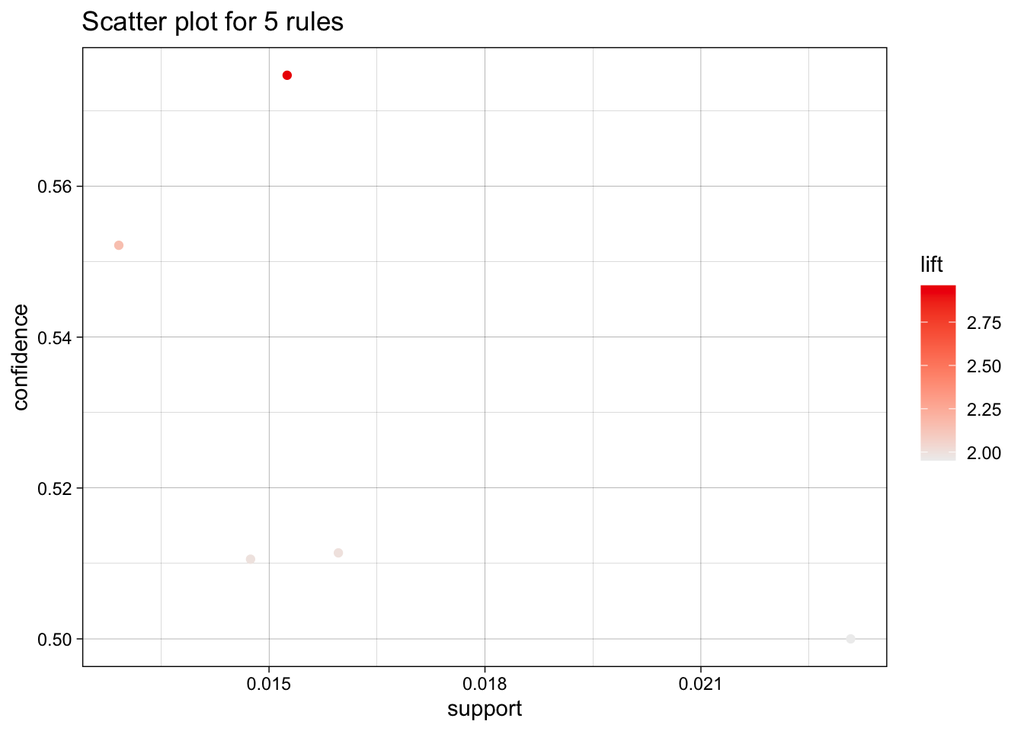

```r
plot(top5_products)
```

```r
inspectDT(top5_products)
```

|  | LHS | RHS | support | confidence | coverage | lift | count |
| --- | --- | --- | --- | --- | --- | --- | --- |
| [19] | {HP Laptop,Lenovo Desktop Computer} | {iMac} | 0.0230808337569903 | 0.5 | 0.0461616675139807 | 1.95216355696705 | 227 |
| [12] | {Acer Desktop,HP Laptop} | {iMac} | 0.0159633960345704 | 0.511400651465798 | 0.0312150482968988 | 1.99667542960148 | 157 |
| [13] | {Dell Desktop,ViewSonic Monitor} | {HP Laptop} | 0.0152516522623284 | 0.574712643678161 | 0.0265378749364515 | 2.96086896310881 | 150 |
| [8] | {Apple Magic Keyboard,HP Laptop} | {iMac} | 0.0147432638535841 | 0.51056338028169 | 0.0288764616166751 | 1.99340644901565 | 145 |
| [4] | {HP Laptop,Microsoft Office Home and Student 2016} | {iMac} | 0.0129130655821047 | 0.552173913043478 | 0.0233858668022369 | 2.15586758030274 | 127 |

```r
Item_Rules2<- subset(rules_product, items %in% "CYBERPOWER Gamer Desktop")
ItemRules2 <- sort(Item_Rules2, by = "support", decreasing = TRUE)
top5_products <- head(ItemRules2, 5)
head(top5_products)
```

```
## set of 2 rules
```

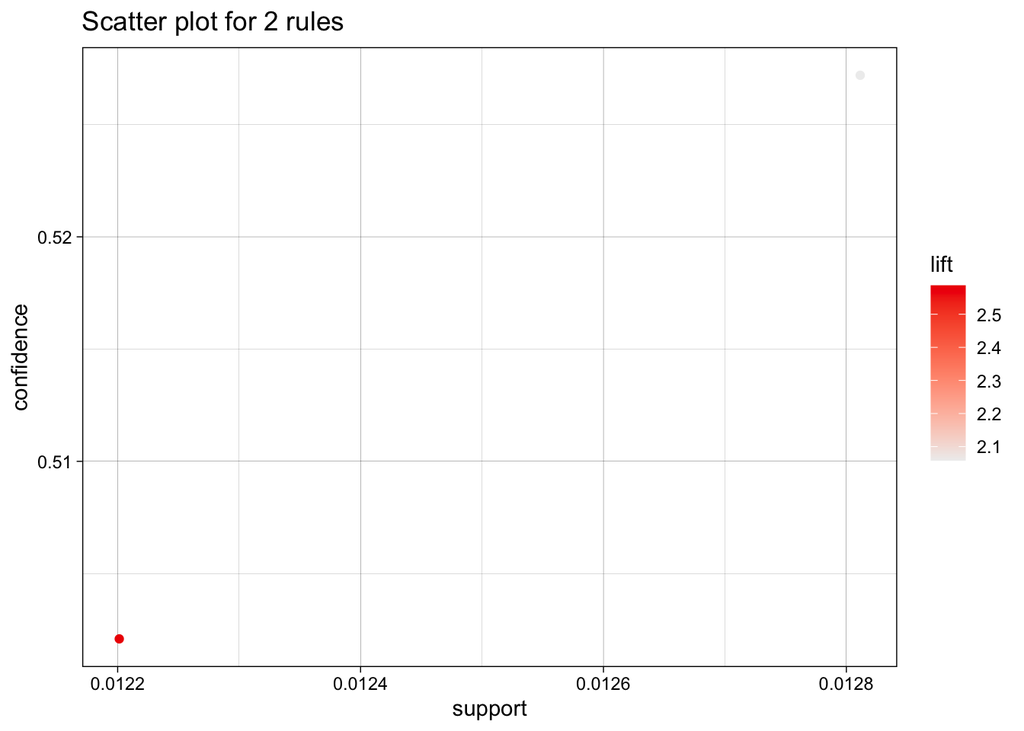

```r
plot(top5_products)
```

```r
inspectDT(top5_products)
```

|  | LHS | RHS | support | confidence | coverage | lift | count |
| --- | --- | --- | --- | --- | --- | --- | --- |
| [16] | {CYBERPOWER Gamer Desktop,ViewSonic Monitor} | {iMac} | 0.0128113879003559 | 0.527196652719665 | 0.0243009659379766 | 2.05834818558869 | 126 |
| [15] | {CYBERPOWER Gamer Desktop,ViewSonic Monitor} | {HP Laptop} | 0.0122013218098627 | 0.502092050209205 | 0.0243009659379766 | 2.5867340564733 | 120 |

#2.Would Blackwell benefit from buying Electronidex?

```r
ItemRules3 <- subset(rules_cat, items %in% "Speakers")
sorted_ItemRules3<- sort(ItemRules3, by = "support", decreasing = TRUE)
top5_Speakers <- head(sorted_ItemRules3, 5)
head(top5_Speakers)
```

```
## set of 5 rules
```

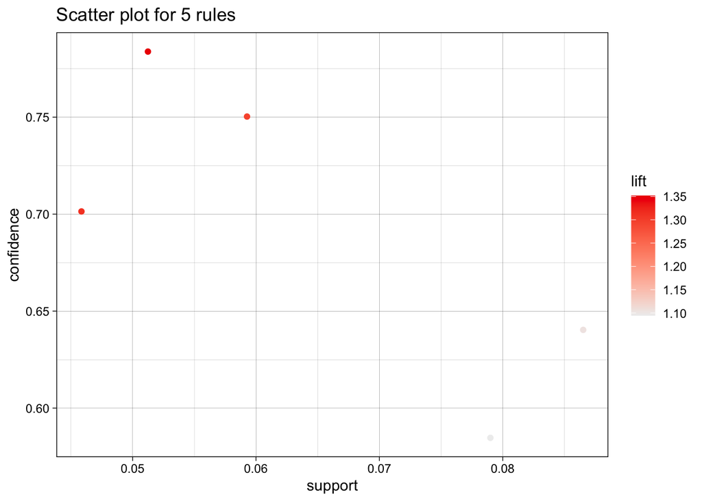

```r
plot(top5_Speakers)
```

```r
inspectDT(top5_Speakers)
```

|  | LHS | RHS | support | confidence | coverage | lift | count |
| --- | --- | --- | --- | --- | --- | --- | --- |
| [27] | {Speakers} | {desktop} | 0.0865189101260675 | 0.64033107599699 | 0.135115900772672 | 1.10418942207335 | 851 |
| [26] | {Speakers} | {laptop} | 0.0789955266368442 | 0.584650112866817 | 0.135115900772672 | 1.09452198518424 | 777 |
| [357] | {laptop,Speakers} | {desktop} | 0.0592720618137454 | 0.75032175032175 | 0.0789955266368443 | 1.2938577728199 | 583 |
| [355] | {monitors,Speakers} | {desktop} | 0.0512403416022773 | 0.783825816485226 | 0.0653721024806832 | 1.35163231608497 | 504 |
| [353] | {monitors,Speakers} | {laptop} | 0.0458519723464823 | 0.701399688958009 | 0.0653721024806832 | 1.31308856882204 | 451 |

```r
ItemRules4 <- subset(rules_cat, items %in% "External Hardrives")
sorted_ItemRules4<- sort(ItemRules4, by = "support", decreasing = TRUE)
top5_External_Hardrives <- head(sorted_ItemRules4, 5)
head(top5_External_Hardrives)
```

```
## set of 5 rules
```

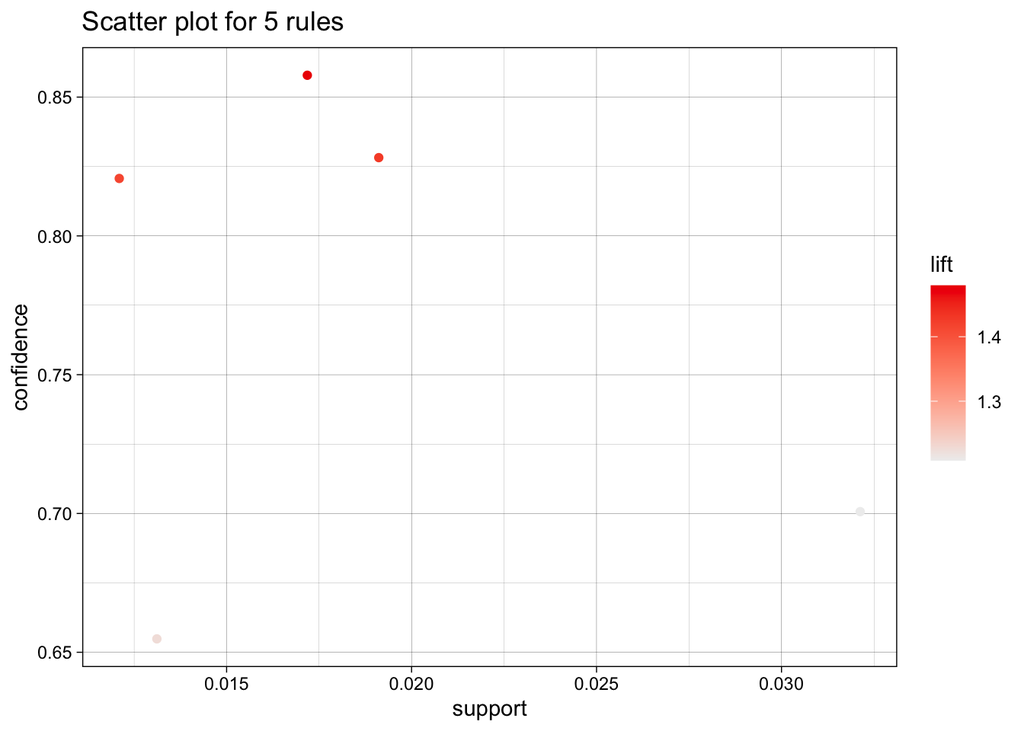

```r
plot(top5_External_Hardrives)
```

```r
inspectDT(top5_External_Hardrives)
```

|  | LHS | RHS | support | confidence | coverage | lift | count |
| --- | --- | --- | --- | --- | --- | --- | --- |
| [4] | {External Hardrives} | {desktop} | 0.0321268808458723 | 0.700665188470067 | 0.0458519723464823 | 1.20822980255813 | 316 |
| [69] | {External Hardrives,laptop} | {desktop} | 0.019113460756405 | 0.828193832599119 | 0.0230784871899146 | 1.42814069730802 | 188 |
| [67] | {External Hardrives,monitors} | {desktop} | 0.0171817812118747 | 0.857868020304569 | 0.0200284668564457 | 1.47931098311987 | 169 |
| [65] | {External Hardrives,monitors} | {laptop} | 0.0131150874339162 | 0.654822335025381 | 0.0200284668564457 | 1.2258912233174 | 129 |
| [61] | {External Hardrives,Keyboard} | {desktop} | 0.0120984139894266 | 0.820689655172414 | 0.0147417649450996 | 1.41520046428399 | 119 |

```r
categories_dict <- c("laptop" = 1650, "desktop" = 1750, "monitors" = 300, "Computer Tablets" = 500, "Computer Mice" = 80, "Keyboard" = 300,
                     "Mouse and Keyboard Combo" = 400, "Active Headphones" = 100, "Computer Headphones" = 150, "Computer Cords" = 30,
                     "Computer Stands" = 60, "Accessories" = 70, "Speakers" = 200, "Printers" = 100, "Printer Ink" = 30,
                     "External Hardrives" = 120, "Smart Home Devices" = 50)


df_category$Average_Price_Category_Transaction <- NA  # Create an empty "Category" column

# Iterate through each row and replace "Category" values based on matching keys in categories_dict
for (i in 1:nrow(df_category)) {
  categories <- unique(unlist(df_category[i,]))
  categories <- categories[!is.na(categories) & categories %in% names(categories_dict)]
  if (length(categories) > 0) {
    df_category$Average_Price_Category_Transaction[i] <- sum(categories_dict[categories])
  }
}

df_category$Average_Price_Category <- rowSums(df_category[, "Average_Price_Category_Transaction", drop = FALSE], na.rm = TRUE)  # Calculate the row sum for the "Category" column

df_category$Average_Price_Category_Transaction <- as.numeric(as.character(df_category$Average_Price_Category_Transaction))

df_category <- na.omit(df_category)
```

```r
summary(df_category$Average_Price_Category_Transaction)
```

```
##    Min. 1st Qu.  Median    Mean 3rd Qu.    Max.
##      30    1650    2120    2340    3700    5590
```

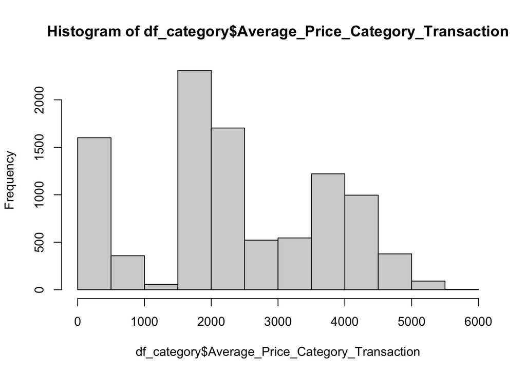

```r
hist(df_category$Average_Price_Category_Transaction)
```

```r
# Initialize the Pricing Strategy column
df_category$Range <- ""

# Set the threshold for transactions made by companies

# Assign the pricing strategy categories based on the price values and transaction type
df_category$Range[df_category$Range < 30] <- "Very Low Price (Light)"

df_category$Range[df_category$Average_Price_Category_Transaction >= 30 & df_category$Average_Price_Category_Transaction < 150] <- "Low"

df_category$Range[df_category$Average_Price_Category_Transaction >= 150 & df_category$Average_Price_Category_Transaction < 500] <- "Standard"

df_category$Range[df_category$Average_Price_Category_Transaction >= 500 & df_category$Average_Price_Category_Transaction < 1250] <- "Mid-High Price"

df_category$Range[df_category$Average_Price_Category_Transaction >= 1250 & df_category$Average_Price_Category_Transaction < 2000] <- "High Price"

df_category$Range[df_category$Average_Price_Category_Transaction >= 2000 & df_category$Average_Price_Category_Transaction < 3000] <- "Premium"

df_category$Range[df_category$Average_Price_Category_Transaction >= 3000] <- "B2B"
```

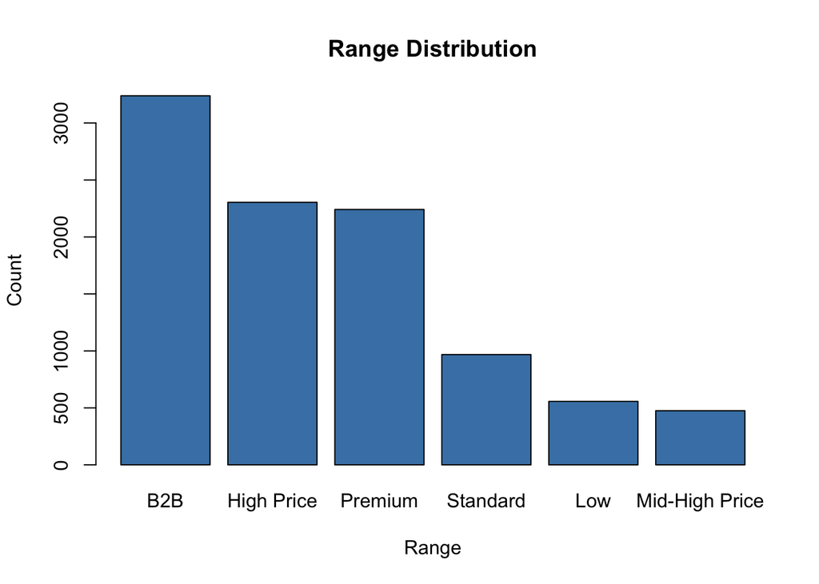

```r
# Count the frequency of each range category
range_counts <- table(df_category$Range)

# Sort the range_counts in descending order
range_counts <- sort(range_counts, decreasing = TRUE)

# Create a vertical bar plot with ordered categories
barplot(range_counts, main = "Range Distribution", xlab = "Range", ylab = "Count", col = "steelblue", ylim = c(0, max(range_counts)))
```

```r
# Calculate the percentage of each range category
percentage <- round((range_counts / sum(range_counts)) * 100, 1)

# Create a cross-tabulation table with percentages
cross_tab <- prop.table(range_counts) * 100
cross_tab <- round(cross_tab, 1)

# Print the cross-tabulation table
cat("\nCross-Tabulation of Range with Percentages:\n")
```

```
##
## Cross-Tabulation of Range with Percentages:
```

```r
print(cross_tab)
```

```
##
##            B2B     High Price        Premium       Standard            Low
##           33.1           23.5           22.9            9.9            5.7
## Mid-High Price
##            4.9
```

```r
# df_category$Rules <- "Other"
#
# for (i in 1:nrow(df_product)) {
#   if (sum(grepl("Laptop", df_product[i, ]) | grepl("Desktop", df_product[i, ]) | grepl("Monitor", df_product[i, ]) |
#           grepl("Keyboard", df_product[i, ]) | grepl("Computer Mice", df_product[i, ]) | grepl("Computer Cords", df_product[i, ]) |
#           grepl("Mouse and Keyboard Combo", df_product[i, ]) | grepl("Computer Headphones", df_product[i, ]) |
#           grepl("Active Headphones", df_product[i, ]) | grepl("Speakers", df_product[i, ]) | grepl("Printers", df_product[i, ]) |
#           grepl("Printer Ink", df_product[i, ]) | grepl("Computer Stands", df_product[i, ]) | grepl("Computer Tablets", df_product[i, ]) |
#           grepl("External Hardrives", df_product[i, ]) | grepl("Smart Home Devices", df_product[i, ])) >= 4) {
#     df_product$Rules[i] <- "Office"
#   }
# }


# for (i in 1:nrow(df_)) {
#   if (sum(
#     grepl("Keyboard", df_product[i,]) |
#     grepl("Computer Mice", df_product[i,]) |
#     grepl("Computer Cords", df_product[i,]) |
#     grepl("Mouse and Keyboard Combo", df_product[i,]) |
#     grepl("Computer Headphones", df_product[i,]) |
#     grepl("Active Headphones", df_product[i,]) |
#     grepl("Speakers", df_product[i,]) |
#     grepl("Printers", df_product[i,]) |
#     grepl("Printer Ink", df_product[i,]) |
#     grepl("Computer Stands", df_product[i,]) |
#     grepl("Computer Tablets", df_product[i,]) |
#     grepl("External Hardrives", df_product[i,]) |
#     grepl("Smart Home Devices", df_product[i,]) |
#     grepl("monitors", df_product[i,])
#   ) >= 1) {
#     df_product$Rules[i] <- "Casual Buyers"
#   }
# }

# for (i in 1:nrow(df_product)) {
#   if (sum(grepl("Laptop", df_product[i,]) | grepl("Desktop", df_product[i,])>= 1) {
#     df_product$Rules[i] <- "Computer"
#   }
# }
```

```r
# # Count the frequency of each range category
# range_counts <- table(df_product$Rules)
#
# # Sort the range_counts in descending order
# range_counts <- sort(range_counts, decreasing = TRUE)
#
# # Create a vertical bar plot with ordered categories
# barplot(range_counts, main = "Range Distribution", xlab = "Range", ylab = "Count", col = "steelblue", ylim = c(0, max(range_counts)))
#
# # Calculate the percentage of each range category
# percentage <- round((range_counts / sum(range_counts)) * 100, 1)
#
# # Create a cross-tabulation table with percentages
# cross_tab <- prop.table(range_counts) * 100
# cross_tab <- round(cross_tab, 1)
#
# # Print the cross-tabulation table
# cat("\nCross-Tabulation of Range with Percentages:\n")
# print(cross_tab)
```